# Inference for Regression with a Mathematical Model

Lesson 35 — Regression Diagnostics and t-based Inference

Lt Col Cho

## Same question, new tool

- **In Lesson 33 we described the sampling distribution of $b_1$ by simulation. Can a formula replace the simulation, as the CLT did for $\bar{x}$ in Lesson 34?**

**Population model** (parameters, unknown)

$$y = \beta_0 + \beta_1 x + \varepsilon$$

**Fitted model** (statistics, from one sample)

$$\hat{y} = b_0 + b_1 x$$

- The **error term** $\varepsilon$ is the difference between $y$ and the population line $\beta_0 + \beta_1 x$. The model assumes:
  1. $\varepsilon$ has mean 0 at every value of $x$;
  2. the errors are independent of one another;
  3. the errors are Normally distributed;
  4. the errors have the same standard deviation $\sigma$ at every value of $x$.
- Compactly: $\varepsilon \sim N(0, \sigma)$, independently.
- $b_1$ is a **random variable**: a different random sample gives a different $b_1$. Hypotheses are about $\beta_1$; the regression table reports $b_1$.

## The sampling distribution of $b_1$

- If the four assumptions hold, the sampling distribution of $b_1$ is approximately Normal, centered at $\beta_1$, with standard error

$$SE(b_1) = \frac{s}{\sqrt{\sum (x_i - \bar{x})^2}}
\qquad s = \text{residual standard deviation (estimates } \sigma)$$

- $SE(b_1)$ decreases when $s$ decreases, when $n$ increases, and when the $x$ values are more spread out. Software computes it.
- **Penguins,** body mass (g) ~ flipper length (mm), $n = 342$. Histogram: 1,000 bootstrap slopes. Curve: $N(b_1, SE(b_1))$.

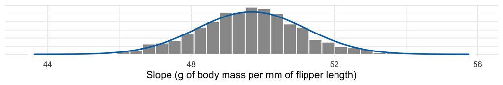

|  | Simulation (Lesson 33) | Formula |
| --- | --- | --- |
| Spread of $b_1$ | bootstrap SD $=$ 1.473 | $SE(b_1) =$ 1.518 |
| 95% CI for $\beta_1$ | (46.77, 52.66) | (46.70, 52.67) |

## Standardizing the slope: $T$

- $s$ estimates $\sigma$, so $SE(b_1)$ is **estimated**. As in Lesson 34, standardizing with an estimated SE gives $T$:

$$T = \frac{b_1 - 0}{SE(b_1)}
\qquad\qquad
T \sim t_{n-2} \ \text{ approximately, if } H_0: \beta_1 = 0 \text{ is true and the conditions hold}$$

- **Degrees of freedom:** $df = n - p$, where $p$ is the number of coefficients in the model, **including the intercept**.

| Model | Coefficients $p$ | $df$ |
| --- | --- | --- |
| One mean (Lesson 34) | 1 ($\mu$) | $n - 1$ |
| Simple regression | 2 ($\beta_0, \beta_1$) | $n - 2$ |
| Multiple regression with $k$ predictors | $k + 1$ | $n - k - 1$ |

- The null value is 0 because $H_0: \beta_1 = 0$ states that $y$ has no linear relationship with $x$.
- **What is $df$ for the penguin model with $n = 342$?**

## Reading the regression table

```r
mass_mod <- lm(body_mass_g ~ flipper_length_mm, data = penguins)
summary(mass_mod)
```

|  | Estimate | Std. Error | t value | Pr(>\|t\|) |
| --- | --- | --- | --- | --- |
| (Intercept) | -5780.83 | 305.81 | -18.90 | $< 2 \times 10^{-16}$ |
| flipper_length_mm | 49.686 | 1.518 | 32.72 | $< 2 \times 10^{-16}$ |

Residual standard error: 394.3 on 340 degrees of freedom

| Column | Symbol | Meaning |
| --- | --- | --- |
| Estimate | $b_j$ | the fitted coefficient from this sample |
| Std. Error | $SE(b_j)$ | the estimated SD of the sampling distribution of $b_j$ |
| t value | $T = b_j / SE(b_j)$ | the number of standard errors between $b_j$ and 0 |
| Pr(>\|t\|) | p-value | two-sided p-value for $H_0: \beta_j = 0$, from $t_{n-p}$ |

- Check: $T = 49.686 / 1.518 = 32.72$. The **test statistic** is $b_j$ (Estimate); the **standardized statistic** is $T$ (t value).

## A slope with a large p-value

- Midterm elections, 29 years: change in House seats for the President’s party vs. the unemployment rate (%). $b_1 = -0.89$, $SE = 0.83$, $T = -1.07$, $df = 27$.

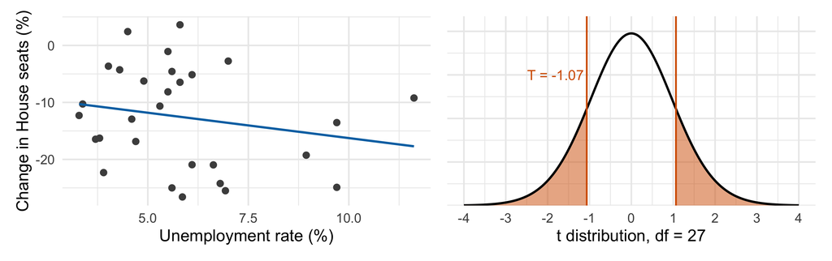

- p-value $=$ `2 * pt(-1.07, df = 27)` $=$ 0.30: the shaded area. **Interpret the p-value in context. What do we conclude at $\alpha = 0.05$?**

## Can we trust the last two columns? LINE

- R prints SEs, $t$ values, and p-values **whether or not** the conditions hold. $T \sim t_{n-p}$ is correct only if they do.

```r
plot(mass_mod)
```

- `plot(mod)` produces four plots; Plots 1–3 are, in order, Residuals vs Fitted, Q-Q Residuals, and Scale-Location. Plot 4 (Residuals vs Leverage) identifies influential points (Lesson 29) and is not used to check LINE.

|  | Assumption about $\varepsilon$ | How to check | Violation |
| --- | --- | --- | --- |
| **L**inearity | mean 0 at every $x$, so the mean of $y$ is $\beta_0 + \beta_1 x$ | scatterplot; Plot 1 (Residuals vs Fitted) | curved pattern; red smoother not flat |
| **I**ndependence | errors are independent | study design: random sample; no repeated measures or time order | not detectable from these plots |
| **N**ormality | errors are Normally distributed | Plot 2 (Q-Q Residuals) | points depart from the dashed line, especially in the tails |
| **E**qual variance | same SD $\sigma$ at every $x$ | Plot 1; Plot 3 (Scale-Location) | funnel shape in Plot 1; red smoother in Plot 3 rises or falls |

- The conditions are about the **errors**, which the residuals $e_i = y_i - \hat{y}_i$ estimate. They are not about the distribution of $x$ or $y$.
- Judge the plots for **large** departures. A minor departure does not invalidate the inference.

## Example A: conditions reasonably met

- Penguins: body mass ~ flipper length.

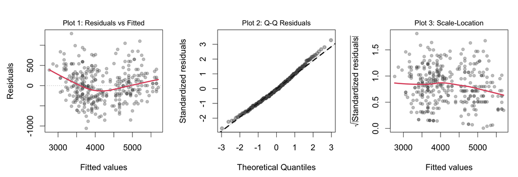

- **L:** Plot 1 smoother is close to flat (slight curvature, small relative to the residual spread). **I:** separate, randomly sampled penguins. **N:** Q-Q points on the line except a few in the upper tail. **E:** Plot 3 smoother close to flat.
- This is why $SE(b_1) =$ 1.518 agreed with the bootstrap SD 1.473.

## Example B: the Lesson 33 model

- Penguins: flipper length ~ bill depth. $b_1 = -4.157$, $SE = 0.314$, $T = -13.26$, p-value $< 0.001$.

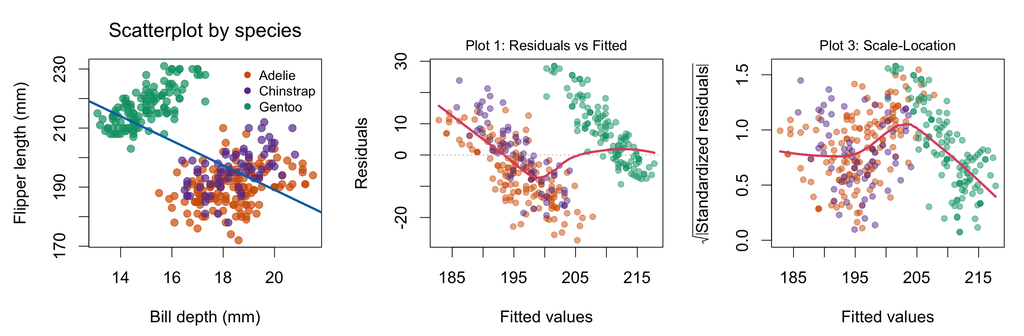

- **L fails:** the Plot 1 smoother falls, then rises. **E fails:** the Plot 3 smoother rises, then falls. Both patterns follow the species groups; within each species the slope is **positive** (1.65, 3.64, 4.67).
- Bootstrap SD of $b_1$ 0.246 vs. reported $SE(b_1) =$ 0.314.

## Example C: Normality and equal variance fail

- Lego sets: price ($) ~ number of pieces, $n = 1065$.

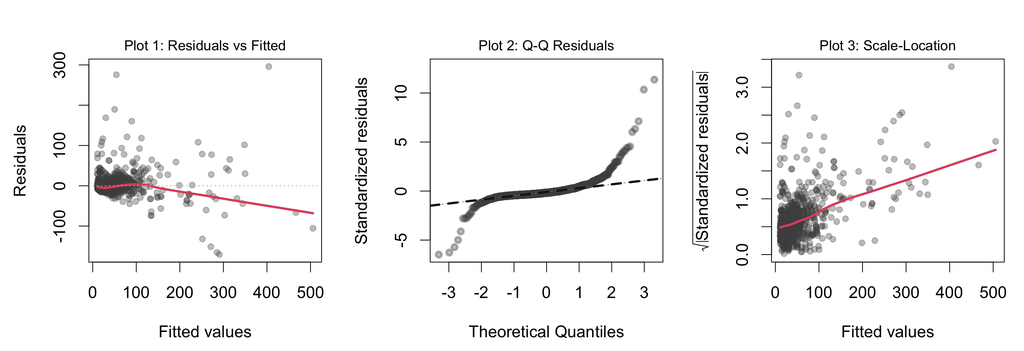

- **E fails:** Plot 1 is a funnel; the Plot 3 smoother rises. **N fails:** the Q-Q plot departs from the line in both tails.

|  | Spread of $b_1$ | 95% CI for $\beta_1$ |
| --- | --- | --- |
| Formula ($t$) | $SE =$ 0.0013 | (0.0797, 0.0847) |
| Bootstrap | SD $=$ 0.0042 | (0.0738, 0.0909) |

## Consequences of each violation

| Violation | Consequence | What to do in this course |
| --- | --- | --- |
| Linearity | the slope does not describe the relationship; all inference on it is misleading | change the model (for example, add a variable) |
| Independence | SEs and p-values are unreliable for both formula and simulation methods | rely on the study design; state that the conclusion is not supported |
| Normality | with large $n$, $t$-based inference remains approximately valid (CLT); a concern mainly for small $n$ | use a bootstrap CI or permutation test, or proceed with caution if $n$ is large |
| Equal variance | the reported SE can be too small or too large, so CIs and p-values are incorrect | use a bootstrap CI |

- **Which row describes Example B? Example C?**
- Simulation methods also require independence. When the conditions fail, the formula SE and the bootstrap SD disagree; when they hold, the two agree.

## Repairing the model: add species

```r
mod_multiple <- lm(flipper_length_mm ~ bill_depth_mm + species, data = penguins)
```

|  | Estimate | Std. Error | t value | Pr(>\|t\|) |
| --- | --- | --- | --- | --- |
| (Intercept) | 136.949 | 5.184 | 26.42 | $< 2 \times 10^{-16}$ |
| bill_depth_mm | 2.889 | 0.281 | 10.27 | $< 2 \times 10^{-16}$ |
| speciesChinstrap | 5.655 | 0.848 | 6.67 | $1.1 \times 10^{-10}$ |
| speciesGentoo | 36.953 | 1.181 | 31.30 | $< 2 \times 10^{-16}$ |

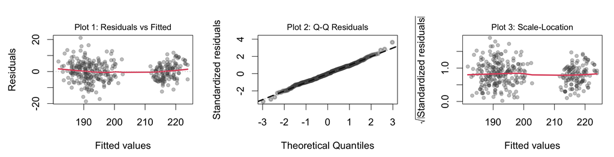

- L, N, and E are now reasonably met. Bootstrap SD of the bill-depth coefficient 0.247 vs. reported SE 0.281.
- Each row tests $H_0: \beta_j = 0$ **given the other variables in the model**. $df = 342 - 4 = 338$.

## Hypothesis test for the bill-depth coefficient

| Step |  |
| --- | --- |
| 0 | $\alpha = 0.05$ |
| 1 | $H_0: \beta_{\text{bill depth}} = 0$: no linear relationship between bill depth and flipper length, given species |
|  | $H_A: \beta_{\text{bill depth}} \neq 0$ |
| 2 | Test statistic: $b_{\text{bill depth}} = 2.889$ mm of flipper length per mm of bill depth |
| 3 | Conditions: L, N, E reasonably met (previous slide); I: penguins sampled independently |
|  | $T = \dfrac{2.889 - 0}{0.2814} = 10.27$, with $T \sim t_{338}$ if $H_0$ is true |
|  | p-value $=$ `2 * pt(-10.27, df = 338)` $< 0.001$ |
| 4 | **?** |

- **Complete Step 4. What does $T = 10.27$ mean?**
- The four steps are the same as in Block 3. Only Step 3 changed: a $t$ distribution replaces the simulated null distribution.

## Confidence intervals for coefficients

$$b_j \pm t^\star_{df} \times SE(b_j)$$

- Bill depth: $2.889 \pm 1.967 \times 0.2814 = (2.34,\ 3.44)$, with $t^\star_{338} =$ `qt(0.975, df = 338)` $= 1.967$.

```r
confint(mod_multiple, level = 0.95)
```

|  | 2.5% | 97.5% |
| --- | --- | --- |
| bill_depth_mm | 2.34 | 3.44 |
| speciesChinstrap | 3.99 | 7.32 |
| speciesGentoo | 34.63 | 39.28 |

- **Interpret the bill-depth interval and the Gentoo interval in context.**
- Lesson 33 bootstrap CI for bill depth: (2.41, 3.40).
- The 95% CI excludes 0 exactly when the two-sided test rejects $H_0$ at $\alpha = 0.05$.

## The other predictors change the p-value

- Black cherry trees, $n = 31$: volume (ft³) predicted from height (ft) and diameter (in).

| Model | Height coefficient | SE | p-value |
| --- | --- | --- | --- |
| `volume ~ height` | 1.543 | 0.384 | 0.0004 |
| `volume ~ height + diam` | 0.339 | 0.130 | 0.0145 |

- Height and diameter are correlated, $r = 0.52$. **Multicollinearity:** two or more predictors are correlated with each other.
- In the second model, the height coefficient estimates the change in mean volume per foot of height **for trees with the same diameter**. That is a different parameter from the slope in the first model.
- **Why is the height coefficient smaller, and its p-value larger, in the second model?**

## The Lesson 33 iris disagreement, resolved

- Iris: `Petal.Width ~ Sepal.Width + Species`, coefficient for sepal width $b = 0.283$.

| Method | Null hypothesis tested | Result |
| --- | --- | --- |
| Bootstrap CI (L33) | none (estimates $\beta_{\text{Sepal.Width}}$) | (0.190, 0.388): excludes 0 |
| Permutation test (L33) | petal width unrelated to **every** predictor | p-value $=$ 0.128 |
| $t$-test (today) | $\beta_{\text{Sepal.Width}} = 0$ **given species** | $T = 6.44$, p-value $= 1.6 \times 10^{-9}$ |
| $t$-based CI (today) | none | (0.197, 0.370): excludes 0 |

- The $t$-test and the bootstrap CI address the same parameter and agree. Shuffling the response tested a different null hypothesis.
- **For one coefficient in a multiple regression, use the $t$-test from the regression table or a bootstrap CI.**

## Simulation vs. mathematical model

|  | Simulation (Lesson 33) | Mathematical model (today) |
| --- | --- | --- |
| Sampling / null distribution | bootstrap / permutation | $t_{n-p}$, from the CLT |
| p-value | proportion of simulated statistics at least as extreme | area under $t_{n-p}$ beyond $\pm T$ |
| Confidence interval | bootstrap percentiles | $b_j \pm t^\star SE(b_j)$ |
| Requires | independence; a randomization that matches $H_0$ | L, I, N, E |
| One coefficient in multiple regression | bootstrap CI | $t$-test and CI from the table |

- When the conditions hold, the two methods give nearly the same SE and CI (Example A). They differ most when the conditions fail (Examples B and C).
- **Procedure for Group Task #4:**
  1. Check Plots 1–3 and the study design.
  2. If L fails, change the model.
  3. If E or N fails (and $n$ is small, for N), report bootstrap CIs.
  4. Otherwise, use `summary()` and `confint()`.

## Practice: murders and poverty

- 20 metropolitan areas: annual murders per million vs. percent in poverty.

|  | Estimate | Std. Error | t value | Pr(>\|t\|) |
| --- | --- | --- | --- | --- |
| (Intercept) | -29.901 | 7.789 | -3.84 | 0.0012 |
| perc_pov | 2.559 | 0.390 | 6.56 | $< 0.0001$ |

1. Write the hypotheses for testing whether poverty percentage is linearly related to the murder rate.
2. State the conclusion of the test at $\alpha = 0.05$ in context.
3. Compute an approximate 95% CI for the slope using $b_1 \pm 2\,SE$.
4. Compute the $t$-based 95% CI. $df = ?$, $t^\star = ?$
5. Do the results of (b) and (d) agree? Explain.

## Practice: baby birth weight

- Random sample of US births (`births14`), $n = 926$: birth weight (lb) predicted from five variables.

|  | Estimate | Std. Error | t value | Pr(>\|t\|) |
| --- | --- | --- | --- | --- |
| (Intercept) | -3.818 | 0.567 | -6.73 | $< 0.0001$ |
| weeks | 0.265 | 0.014 | 18.93 | $< 0.0001$ |
| mage | 0.016 | 0.006 | 2.53 | 0.0115 |
| sexmale | 0.370 | 0.070 | 5.30 | $< 0.0001$ |
| visits | 0.018 | 0.009 | 2.09 | 0.0373 |
| habitsmoker | -0.429 | 0.126 | -3.41 | 0.0007 |

1. Write the hypotheses for the `habitsmoker` coefficient.
2. State the conclusion at $\alpha = 0.05$ and interpret the coefficient in context.
3. What are the degrees of freedom for these tests?
4. Which plots would you examine before trusting the p-values?

```r
plot(lm(weight ~ weeks + mage + sex + visits + habit, data = births14))
```

## Practice: check the conditions

- Penguins: flipper length ~ bill length, $n = 342$.

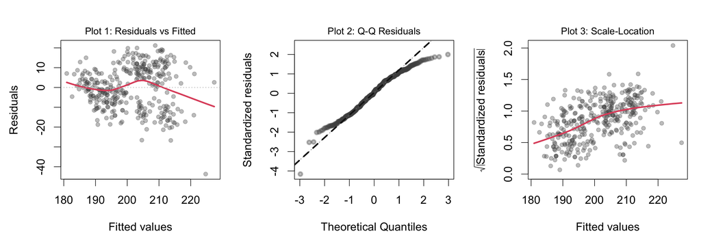

1. For each of L, N, and E, state whether the condition is reasonably met, citing a specific plot.
2. How would you justify (or question) independence?
3. Should we report the $t$-based CI for the slope or a bootstrap CI?